# Pantaleo - Exploratory Analysis - TFH146

## 3.4 Seurat Analysis

Seurat analysis using the normalized dataset. It includes the removing of unwanted sources of variation, PCA, clustering and tSNE. All analyses are done as in Gierhan et al. (2017).

The single cell dataset likely contains *uninteresting* sources of variation. This could include not only technical noise, but batch effects, or even biological sources of variation (cell cycle stage). As suggested in Buettner et al. (2015), regressing these signals out of the analysis can improve downstream dimensionality reduction and clustering. Seurat implements a basic version of this by constructing linear models to predict gene expression based on user-defined variables. Seurat stores the z-scored residuals of these models in the scale.data slot, and they are used for dimensionality reduction and clustering. We typically regress out cell-cell variation in gene expression driven by batch (if applicable), cell alignment rate (as provided by Drop-seq tools for Drop-seq data), the number of detected molecules and mitochondrial gene expression. For cycling cells, we can also learn a cell-cycle score (as in Macosko et al. (2015)) and Regress this out as well - from Gierhan et al. (2017).  
Here, we simply regress on the number of detected molecules per cell as well as the percentage mitochondrial gene content.

```r
###--- Regress out unwanted sources of variation
mito.genes <- grep("^MT-", rownames(seuratObj_TFH_global@data), value = TRUE)
percent.mito <- colSums(as.matrix(expm1(seuratObj_TFH_global@data[mito.genes, ]))) / colSums(as.matrix(expm1(seuratObj_TFH_global@data)))
seuratObj_TFH_global <- AddMetaData(seuratObj_TFH_global, percent.mito, 'percent.mito')
GenePlot(seuratObj_TFH_global, 'nUMI', 'percent.mito')
GenePlot(seuratObj_TFH_global, 'nUMI', 'nGene')
#- remove unwanted sources of variation
seuratObj_TFH_global <- RegressOut(seuratObj_TFH_global, latent.vars = c('nUMI', 'percent.mito')) # remove effect of CDR (high correlation between nGene and nUMI - 0.97) and mitochondrial
```

After, Seurat calculates highly variable genes and focuses on these for downstream analysis.

```r
###--- Detection of variable genes across the single cells
seuratObj_TFH_global <- MeanVarPlot(seuratObj_TFH_global, fxn.x = expMean, fxn.y = logVarDivMean, x.low.cutoff = 0.25, x.high.cutoff = 3, y.cutoff = 0.5, do.contour = FALSE)
length(seuratObj_TFH_global@var.genes) # 1,228 highly variable genes
```

We identified 1,228 variable genes with log-mean expression values greater than 0.25 and dispersion (variance/mean) greater than 0.5.

```r
###--- PCA
#- PCA performed on the scaled data and using only highly variable genes - with correction
seuratObj_TFH_global <- PCA(seuratObj_TFH_global, pc.genes = seuratObj_TFH_global@var.genes)
seuratObj_TFH_global <- ProjectPCA(seuratObj_TFH_global)
```

We can identify markers that are strongly correlated with cellular heterogeneity - see above.

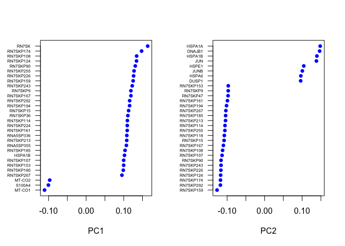

A lot of results related to RN-like genes (pseudogenes - 7SK Small Nuclear Pseudogene)… Should I remove them? First, let’s look at the tSNE plot.

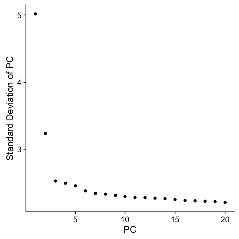

```r
###--- tSNE
seuratObj_TFH_global <- RunTSNE(seuratObj_TFH_global, dims.use = 1:10, perplexity = 50)
```

Let’s look at the tSNE plots now - perplexity of 50 and 1,000 iterations.

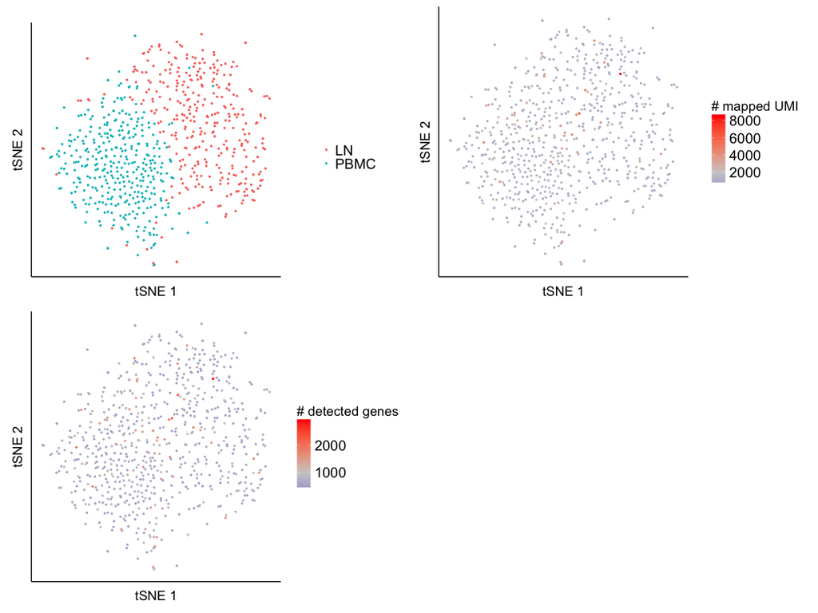

We clearly observe a strong effect between LN and PBMC, such as in HIV+.

Now let’s look at several CD4 T cells / TFHs markers.

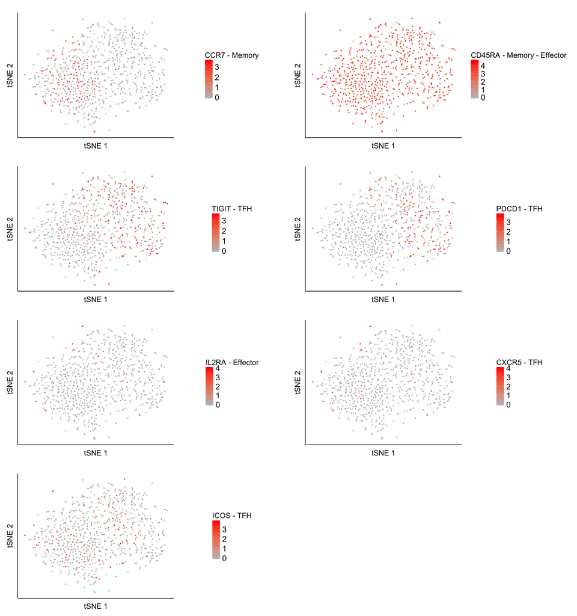

We clearly observe TFH for LN - it makes sense - good quality here. We also see some TFH like in PBMC.

Let’s look at some specific markers found in the paper Raph sent me (06/09/17). In HIV-1 infected individuals, they demonstrated a significant increase (2-3 fold) in the TFH cells defined by the CXCR3+Tbet+ phenotype and IFN-$γ$/IL21 production along with a significant decrease (2-3 fold) in TFH cells expressing CCR4, CCR6 and producing IL-4. So here, I’d like to see the expression of those specific marker. *NB: Here - only HIV-, but let’s give it a try.*

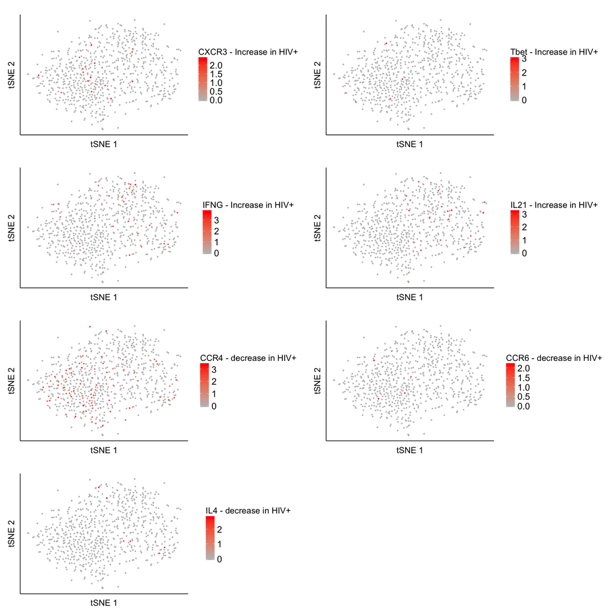

## 3.5 MAST Analysis

Let’s get DEGs between LN and PBMC (TFH cells).

```r
###--- MAST
#- MAST object
pData <- data.frame(cellNames = colnames(seuratObj_TFH_global@data),
                    Condition = unlist(str_split(colnames(seuratObj_TFH_global@data), '_'))[seq(2, length(unlist(str_split(colnames(seuratObj_TFH_global@data), '_'))), 2)])
fData <- data.frame(symbol = rownames(seuratObj_TFH_global@data))
scaTFH <- FromMatrix(as.matrix(seuratObj_TFH_global@data), cData = pData, fData = fData)
scaTFH <- MAST::primerAverage(scaTFH, geneGroups = 'symbol') # Average expression values for duplicated/redundant genes
colData(scaTFH)$cngeneson <- scale(colSums(assay(scaTFH) > 0)) # CDR
rownames(scaTFH) <- rowData(scaTFH)$primerid # change row names
#- New MAST object - keep gene with freq > 0.05
scaTFH <- scaTFH[(freq(scaTFH) > 0.05), ] # threshold of the proportion of expression for each gene - 0.05
scaTFH # 3,884 genes & 705 single-cells
```

Single-cell gene expression data are known to be zero-inflated and bimodal, which is a feature we observe here as well (see below) - that’s why I use MAST instead of limma.

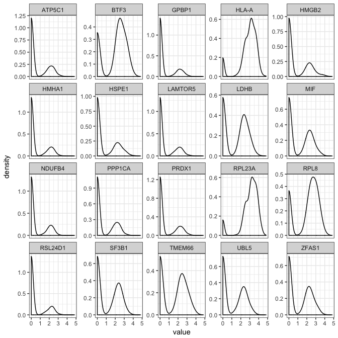

No adaptative thresholding - values tend to 0 - such as with Kelly’s data.

Let’s perform MAST.

```r
###--- DE analysis / Hurdle model
#- zlm model
colData(scaTFH)$Condition
zlmCond <- zlm(~ Condition + cngeneson, scaTFH, method = 'bayesglm', ebayes = TRUE,
               ebayesControl = list(method = "MLE", model = "H1"),
               hook = deviance_residuals_hook) # Hurdle model with cluster & CDR
saveRDS(zlmCond, file = 'Output_061917/zlmCond_LNvsPBMC_TFHcells.rds') # save within .rds file

#- Significant results
hypothesisCluster <- c('ConditionPBMC')
registerDoMC(2)
fcHurdle <- foreach(i=1:length(hypothesisCluster)) %dopar%
{
  summaryCond.temp <- summary(zlmCond, doLRT=hypothesisCluster[i]) # Make contrast with the selected hypothesis
  summaryDt.temp <- summaryCond.temp$datatable # Summary (data.table)
  fcHurdle.temp <- merge(summaryDt.temp[contrast == hypothesisCluster[i] & component == 'H', .(primerid, `Pr(>Chisq)`)], # Hurdle unadjusted p-value
                         summaryDt.temp[contrast == hypothesisCluster[i] & component == 'logFC', .(primerid, coef, ci.hi, ci.lo)], # log2 FoldChange coefficient
                         by='primerid')
  fcHurdle.temp[, FDR := p.adjust(`Pr(>Chisq)`, 'fdr')] # FDR adjusted p-value
  return(fcHurdle.temp)
}
names(fcHurdle) <- hypothesisCluster
registerDoMC(2)
fcHurdleSign <- foreach(i=1:length(hypothesisCluster)) %dopar%
{
  fcHurdle.temp <- fcHurdle[[i]]
  fcHurdleSign.temp <- merge(fcHurdle.temp[FDR < 0.05 & abs(coef) > log2(1.5)], # FDR 5% & FoldChange log2(1.5)
                             as.data.frame(rowData(scaTFH)),
                             by='primerid') # keep only singificant results
  setorder(fcHurdleSign.temp, FDR) # Order according to FDR p-values
  return(fcHurdleSign.temp)
}
names(fcHurdleSign) <- hypothesisCluster
dim(fcHurdleSign[[1]]) # 61 DEGs

#- Output
write.csv(fcHurdleSign[[1]], file = 'Output_061917/DEGs_LNvsPBMC_TFH.csv')
```

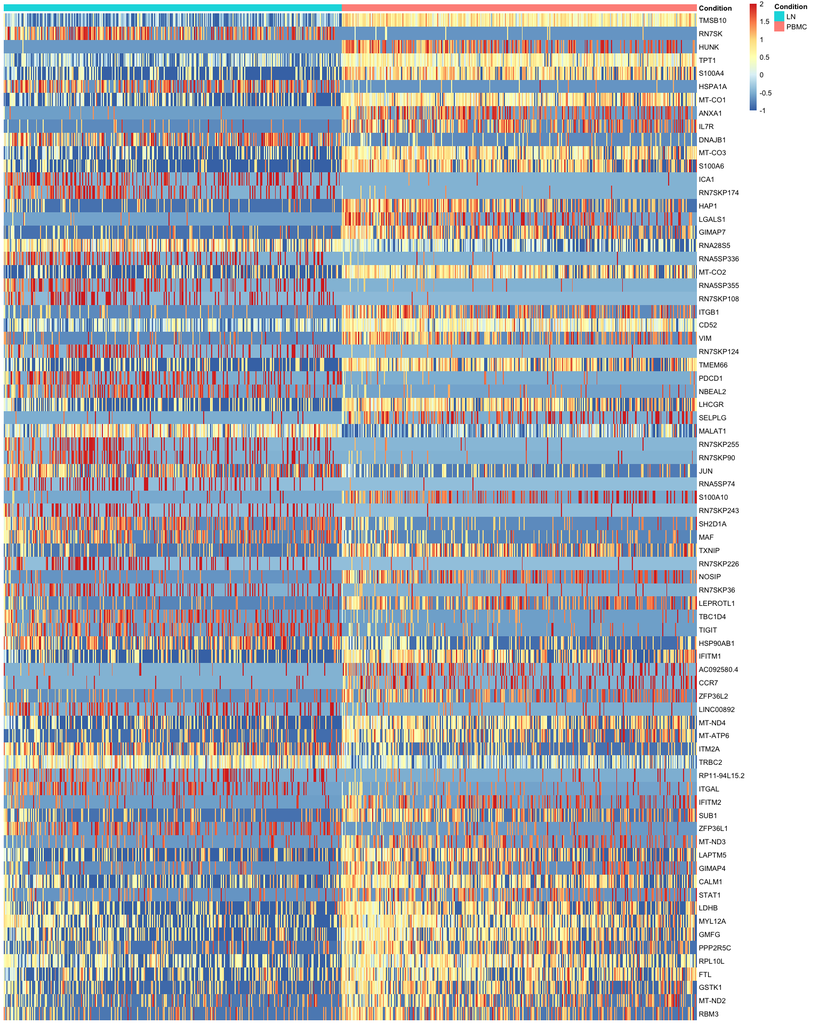

We see that TIGIT, PD1 and MAF (might induced CXCR5 expression and IL21 - BCL6 + MAF cooperates in the induction of CXCR4, PD1 and ICOS - see Kroenke et al (2012) - J Immunol.) are DEs.

We still observe the RN-like genes (pseudogenes - 7SK Small Nuclear Pseudogene).